DS 6030 | Fall 2024 | University of Virginia

# Homework1 Supervised Learning

Author

Courtney Hodge

Published

September 10, 2024

# Required R packages and Directories

```r
library(tidyverse) # functions for data manipulation
library(tibble)
```

# Problem 1: Evaluating a Regression Model

## a. Data generating functions

Create a set of functions to generate data from the following distributions:

**Solution**

```r
sim_x <- function(n) runif(n)         #U[0,1]
f <-function(x) -1 + 0.5*x + 0.2*x^2  #true mean function
sim_y <- function(x, sd) {            #generate Y|X from N{f(x), sd}
  n = length(x)
  f(x) + rnorm(n, mean = 0, sd = sd)
}
```

## b. Generate training data

Simulate $n=100$ realizations from these distributions using $\sigma=3$. Produce a scatterplot and draw the true regression line $f(x) = E[Y \mid X=x]$.

- Use `set.seed(611)` prior to generating the data.

**Solution**

```r
#-- Settings
n = 100       #number of observations
sd = 3        #stdev for error

set.seed(611) # set seed for reproducibility
x = sim_x(n)  # get x values
y = sim_y(x, sd = sd) # get y values
data_train = tibble(x, y) # training data tibble

#----------DELETE ME-------------#
#-- Generate Test Data
ntest = 50000 # Number of test samples
set.seed(611) # set *different* seed
xtest = sim_x(ntest) # generate test X's
ytest = sim_y(xtest, sd=sd) # generate test Y's
data_test = tibble(x=xtest, y=ytest) # test data
```

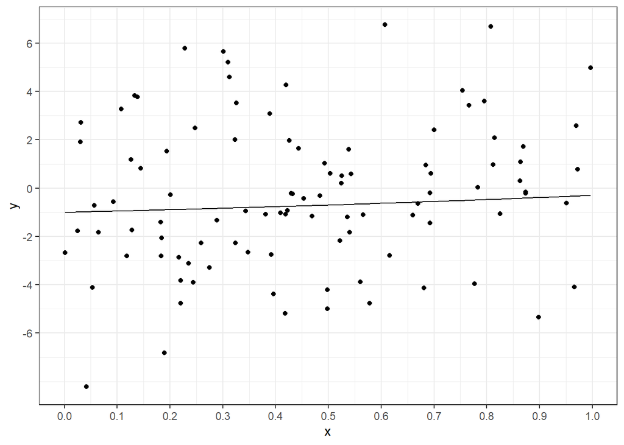

```r
#-- plot points and true regression function
scatter_plot <- ggplot(data_train, aes(x,y)) +
geom_point() +
geom_function(fun = f) +
scale_x_continuous(breaks=seq(0, 1, by=.10)) +
scale_y_continuous(breaks=seq(-6, 10, by=2))

scatter_plot
```

## c. Fit three models

Fit three polynomial regression models using least squares: linear, quadratic, and cubic. Produce another scatterplot, add the fitted lines and true population line $f(x)$ using different colors, and add a legend that maps the line color to a model.

- Note: The true model is quadratic, but we are also fitting linear (less complex) and cubic (more complex) models.

**Solution**

```r
linear_model <- lm(y~poly(x,1), data = data_train)
quadratic_model <-lm(y~poly(x,2), data = data_train)
cubic_model <-lm(y~poly(x,3), data=data_train)

x_seq <- seq(min(data_train$x), max(data_train$x), length.out = 100)


# Assuming sim_y without error (sd=0) represents the true quadratic model
y_true <- sim_y(x_seq, sd = 0)  # True quadratic model without noise

y_linear_pred <- predict(linear_model, newdata = data.frame(x = x_seq))
y_quadratic_pred <- predict(quadratic_model, newdata = data.frame(x = x_seq))
y_cubic_pred <- predict(cubic_model, newdata = data.frame(x = x_seq))
```

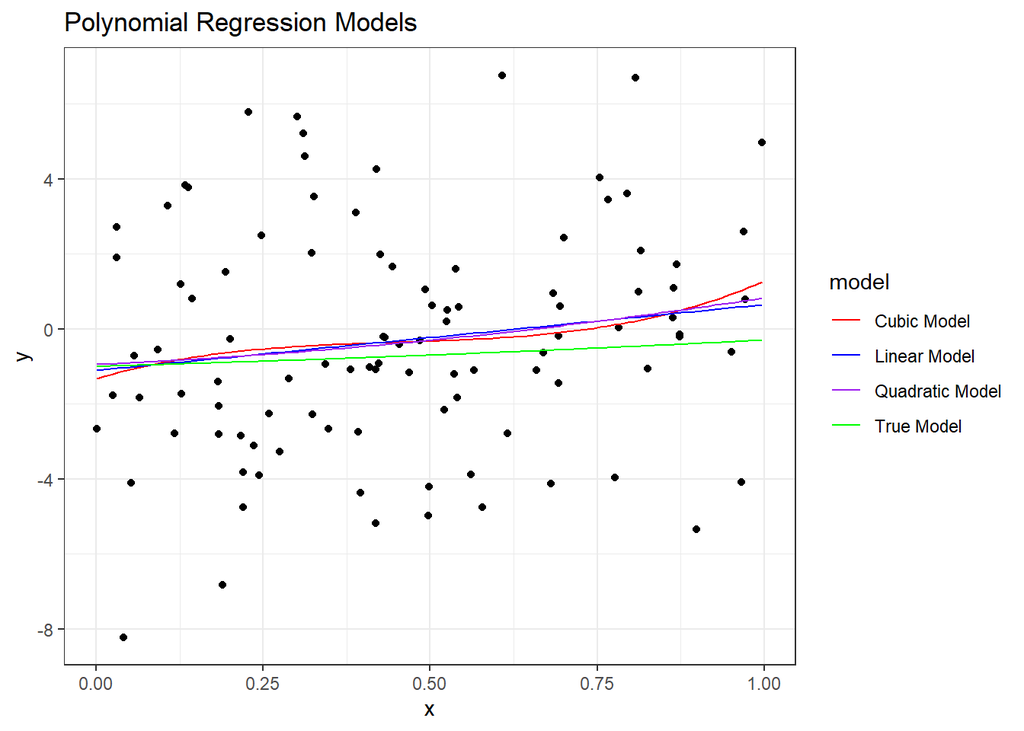

```r
# Create a sequence of x values for plotting the fitted lines
x_seq <- seq(min(data_train$x), max(data_train$x), length.out = 100)

# Combine the predicted values into one data frame for plotting
fit_data <- tibble(
  x = rep(x_seq, 4),
  y = c(y_linear_pred, y_quadratic_pred, y_cubic_pred, y_true),
  model = factor(rep(c("Linear Model", "Quadratic Model", "Cubic Model", "True Model"), each = 100))
)

# Create the ggplot
ggplot(data_train, aes(x = x, y = y)) +
  geom_point() +  # Scatter plot of the data
  geom_line(data = fit_data, aes(x = x, y = y, color = model)) +  # Fitted lines
  labs(title = "Polynomial Regression Models", x = "x", y = "y") +
  scale_color_manual(values = c("red", "blue", "purple", "green"))
```

## d. Predictive performance

Generate a *test data* set of 10,000 observations from the same distributions. Use `set.seed(612)` prior to generating the test data.

- Calculate the estimated mean squared error (MSE) for each model.
- Are the results as expected?

**Solution**

```r
sim_x <- function(n) runif(n)         #U[0,1]
f <-function(x) -1 + 0.5*x + 0.2*x^2  #true mean function
sim_y <- function(x, sd) {            #generate Y|X from N{f(x), sd}
  n = length(x)
  f(x) + rnorm(n, mean = 0, sd = sd)
}

#-- Generate Test Data
ntest = 10000 # Number of test samples
set.seed(612) # set *different* seed
xtest = sim_x(ntest) # generate test X's
ytest = sim_y(xtest, sd=sd) # generate test Y's
data_test = tibble(x=xtest, y=ytest) # test data


linear_yhat = predict(linear_model, data_test)
quadratic_yhat = predict(quadratic_model, data_test)
cubic_yhat = predict(cubic_model, data_test)

#: calculate test MSE
linear_mse_test = mean( (data_test$y - linear_yhat)^2 )
quadratic_mse_test = mean((data_test$y - quadratic_yhat) ^2 )
cubic_mse_test = mean((data_test$y - cubic_yhat) ^ 2)

linear_mse_test
```

```
[1] 9.18
```

```r
quadratic_mse_test
```

```
[1] 9.2
```

```r
cubic_mse_test
```

```
[1] 9.23
```

> The results are as expected. The linear MSE is the lowest but is very close to the quadratic mse. The difference is very small though. The Cubic MSE is larger than linear and quadratic’s showing that the cubic model might be overfitting b/c of unnecessary complexity. The noise is captured rather than the true underlying relationship.

## e. Optimal performance

What is the best achievable MSE? That is, what is the MSE if the true $f(x)$ was used to evaluate the test set? How close does the best method come to achieving the optimum?

**Solution**

> The best achievable MSE are quadratic and linear because they come closer to the best achievable MSE of 9 than cubic does. This value of 9 comes from the variance of the noise in the data. Since the linear model performs with an MSE of 9.1767 and the quadratic model performs with an MSE of 9.1992, they are therefore very close at achieving the optimum.

## f. Replication

The MSE scores obtained in part *d* came from one realization of training data. Here will we explore how much variation there is in the MSE scores by replicating the simulation many times.

- Re-run parts b. and c. (i.e., generate training data and fit models) 100 times.
  - Do not generate new testing data
  - Use `set.seed(613)` prior to running the simulation and do not set the seed in any other places.
- Calculate the test MSE for all simulations.
  - Use the same test data from part d. (This question is only about the variability that comes from the *training data*).
- Create kernel density or histogram plots of the resulting MSE values for each model.

**Solution**

```r
#--function to calculate MSE
calc_mse <- function(model, data_test){
  y_pred <- predict(model, newdata = data_test)
  mean((data_test$y - y_pred)^2)
}

#--set up num of simulations
n_simulations = 100

#--set the simulation seed
set.seed(613)

#--Create vector to store MSE values for each model
mse_linear <- numeric(n_simulations)
mse_quadratic <- numeric(n_simulations)
mse_cubic <- numeric(n_simulations)

#-- start the simulation
for (i in 1:n_simulations){
  #generate new training data each time
  x_train = sim_x(100)
  y_train = sim_y(x_train, sd = 3)
  data_train = tibble(x = x_train, y = y_train)

  #fit the models
  linear_model <- lm(y~ poly(x, 1), data = data_train)
  quadratic_model <- lm(y~poly(x,2), data = data_train)
  cubic_model <- lm(y~poly(x,3), data = data_train)

  #calculate the MSE for each model using the test data
  mse_linear[i] <-calc_mse(linear_model, data_test)
  mse_quadratic[i] <-calc_mse(quadratic_model, data_test)
  mse_cubic[i] <- calc_mse(cubic_model, data_test)
}
```

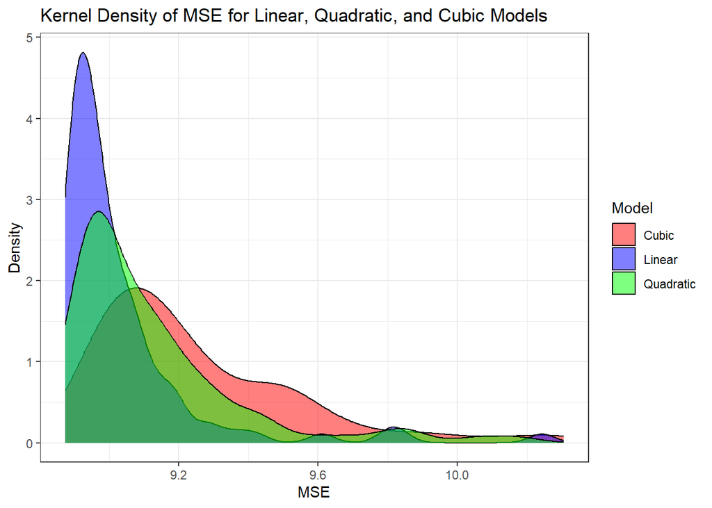

```r
#--plot the MSE distributions
mse_data <- tibble(
  MSE = c(mse_linear, mse_quadratic, mse_cubic),
  Model = rep(c("Linear", "Quadratic", "Cubic"), each = n_simulations)
)

# Kernel Density Plot
ggplot(mse_data, aes(x = MSE, fill = Model)) +
  geom_density(alpha = 0.5) +
  labs(title = "Kernel Density of MSE for Linear, Quadratic, and Cubic Models",
       x = "MSE", y = "Density") +
  scale_fill_manual(values = c("red", "blue", "green"))
```

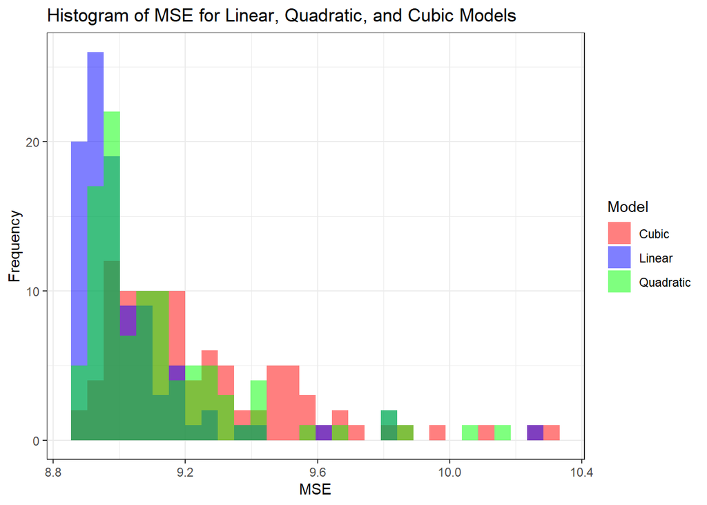

```r
#--histogram plot
ggplot(mse_data, aes(x = MSE, fill = Model)) +
  geom_histogram(bins = 30, position = "identity", alpha = 0.5) +
  labs(title = "Histogram of MSE for Linear, Quadratic, and Cubic Models",
       x = "MSE", y = "Frequency") +
  scale_fill_manual(values = c("red", "blue", "green"))
```